# Experience vs. description based decision-making project: DDM parameter recovery multiple round optimization

# Setup

Set up environment and load in data

# 3 parameter model

Recovery exercises both on random datasets, as well as, on a grid of delta and gamma showed a correlation between these parameters and therefore issues in identifiability.

Motivated also by the logit analyses for the whole sample, which showed that while the weight of EVs decreased monotonically, weight of QVs followed more a step function/was possibly consistently underweighted I decided to switch the probability distortion function to a single parameter one.

In this notebook I look at how well the parameters of a now three parameter model (d, sigma, delta) are recovered using two different optimization methods.

To understand how well recovery works (especially for delta) using a three parameter model (d, sigma, delta) I systematically varied each parameter and generated 36 datasets to optimize over. The datasets were generated using the combination of the true values `true_ds = c(.001, .06 , .5)`, `true_sigmas = c(.001, .08, .3)`, `true_deltas = c(.1, .5 , 1, 3)`.

## Data and helper functions

```r
optim_out_path = paste0(cpueaters_path, 'ddModels/cluster_scripts/optim_out/')
true_pars_path = paste0(helpers_path, 'ddModels/cluster_scripts/test_data/')

model = "model1c"
data_suffix = "sim_single_sub_data"

data_nums = c(46:81)
sim_types = c("sim3", "sim3b")

# Note this takes a little bit
comp_data = data.frame()

for(i in 1:length(data_nums)){
  cur_data_num = data_nums[i]
  for(j in 1:length(sim_types)){
    cur_sim_type = sim_types[j]
    cur_out = ddm_par_recovery_report(model_ = model, data_ = paste0(data_suffix,cur_data_num), optim_out_path_= paste0(optim_out_path, cur_sim_type, '/'), true_pars_path_ = true_pars_path, diff_pct_plots_ = TRUE)$diff_pct_data
    cur_out$sim_type = cur_sim_type
    cur_out$data_num = as.character(cur_data_num)
    comp_data = rbind.all.columns(comp_data, cur_out)
  }
}
```

```r
plot_heatmaps = function(x_par = "d", y_par = "sigma", fill_par = "delta", plt_sim_type = "sim3"){

  comp_data = comp_data %>%
    mutate(true_val = as.factor(true_val)) %>%
    filter(sim_type == plt_sim_type)

  tmp1 = comp_data %>%
    filter(key == x_par) %>%
    select(key, true_val, data_num) %>%
    spread(key, true_val)

  tmp2 = comp_data %>%
    filter(key == y_par) %>%
    select(key, true_val, data_num) %>%
    spread(key, true_val)

  tmp3 = comp_data %>%
    filter(key == fill_par) %>%
    select(key, true_val, data_num) %>%
    spread(key, true_val) %>%
    rename(true_val = fill_par)

  tmp4 = comp_data %>%
    filter(key == fill_par) %>%
    select(key, median_diff, data_num) %>%
    spread(key, median_diff) %>%
    rename(median_diff = fill_par)

  p = tmp1 %>%
    left_join(tmp2, by="data_num") %>%
    left_join(tmp3, by="data_num") %>%
    left_join(tmp4, by="data_num") %>%
    mutate(median_diff_clipped = ifelse(median_diff>100, 101, median_diff)) %>%
    ggplot(aes_string(x=x_par, y=y_par))+
    geom_tile(aes(fill=median_diff_clipped))+
    facet_grid(.~true_val)+
    theme(legend.position = "bottom")+
    labs(x=x_par, y=y_par, fill=paste0("Median % difference between true and estimated ", fill_par))
  return(p)
}
```

## Sim3: Single round optimization

```r
fig_fn = 'ddm_recovery_sim3'
```

How bad was delta recovery for each combination of d and sigma (3 by 3 heatmap) panels for each value of delta (4 panels)  
How bad was d recovery for each combination of delta and sigma (3 by 4 heatmap) panels for each value of d (3 panels)  
How bad was sigma recovery for each combination of d and delta (3 by 4 heatmap) panels for each value of sigma (3 panels)

```r
p1 = plot_heatmaps(x_par = "d", y_par = "sigma", fill_par = "delta") +
  theme(legend.margin=margin(0,0,0,0), legend.box.margin=margin(-10,-10,0,-10))
p2 = plot_heatmaps(fill_par = "d", y_par = "sigma", x_par = "delta") +
  theme(legend.margin=margin(0,0,0,0), legend.box.margin=margin(-10,-10,0,-10))
p3 = plot_heatmaps(y_par = "d", fill_par = "sigma", x_par = "delta") +
  theme(legend.margin=margin(0,0,0,0), legend.box.margin=margin(-10,-10,0,-10))
```

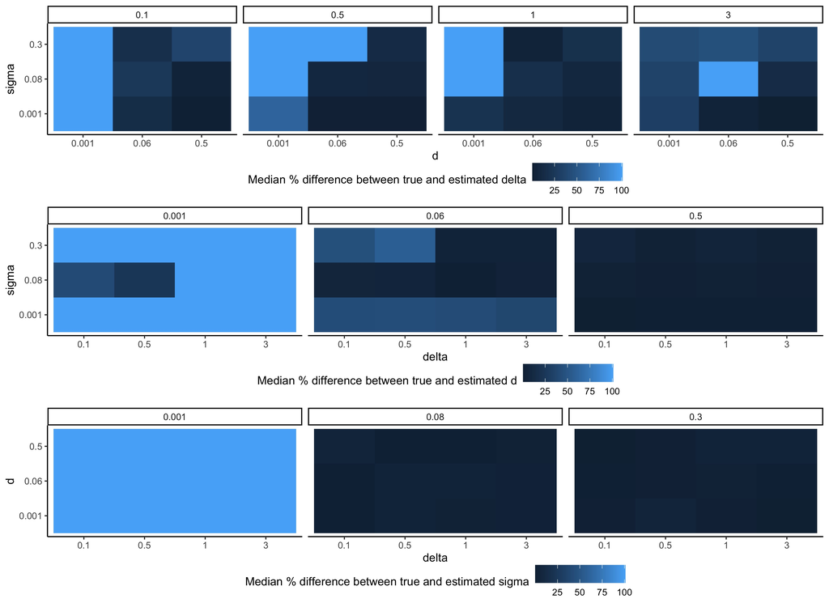

```r
g = arrangeGrob(grobs=list(p1, p2, p3), nrow=3)
# ggsave(file=paste0(fig_out_path, fig_fn, '_diff_pct_heatmaps.jpg'), g, height = 8, width=11, units="in")
ggsave(file=paste0(fig_out_path, fig_fn, '_diff_pct_heatmaps.pdf'), g, height = 8, width=11, units="in")
```

**Conclusion:**  
- When d is very small (.001) delta < 1 can’t be recovered.  
- Delta can recovered with some success for medium and high values of d and medium and low values of sigma.  
- For the sample parameters I tried initially (d=.06, sigma=.08, delta=3) delta recovery is particularly poor compared to other cases when delta=3.  
- When d and sigma are very small (0.001) they can’t be recovered.  
- d can be successfully recovered for other cases with lower difference from true value as the true value of d increases.  
- sigma can be successfull recovered when not very small.

## Sim3b: Two round optimization

```r
fig_fn = 'ddm_recovery_sim3b'
```

How bad was delta recovery for each combination of d and sigma (3 by 3 heatmap) panels for each value of delta (4 panels)  
How bad was d recovery for each combination of delta and sigma (3 by 4 heatmap) panels for each value of d (3 panels)  
How bad was sigma recovery for each combination of d and delta (3 by 4 heatmap) panels for each value of sigma (3 panels)

```r
p1 = plot_heatmaps(x_par = "d", y_par = "sigma", fill_par = "delta", plt_sim_type = "sim3b") +
  theme(legend.margin=margin(0,0,0,0), legend.box.margin=margin(-10,-10,0,-10))
p2 = plot_heatmaps(fill_par = "d", y_par = "sigma", x_par = "delta", plt_sim_type = "sim3b") +
  theme(legend.margin=margin(0,0,0,0), legend.box.margin=margin(-10,-10,0,-10))
p3 = plot_heatmaps(y_par = "d", fill_par = "sigma", x_par = "delta", plt_sim_type = "sim3b") +
  theme(legend.margin=margin(0,0,0,0), legend.box.margin=margin(-10,-10,0,-10))
```

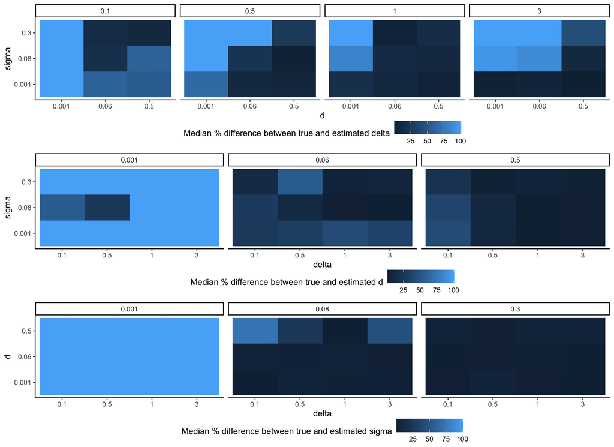

```r
g = arrangeGrob(grobs=list(p1, p2, p3), nrow=3)
ggsave(file=paste0(fig_out_path, fig_fn, '_diff_pct_heatmaps.pdf'), g, height = 8, width=11, units="in")
```

## Comparison of sim3 and sim3b

Scatter plot of median percentage difference from true value for single round (x-axis) vs two round (y-axis) for each parameter

```r
fig_fn = 'ddm_recovery_sim3_sim3b'
```

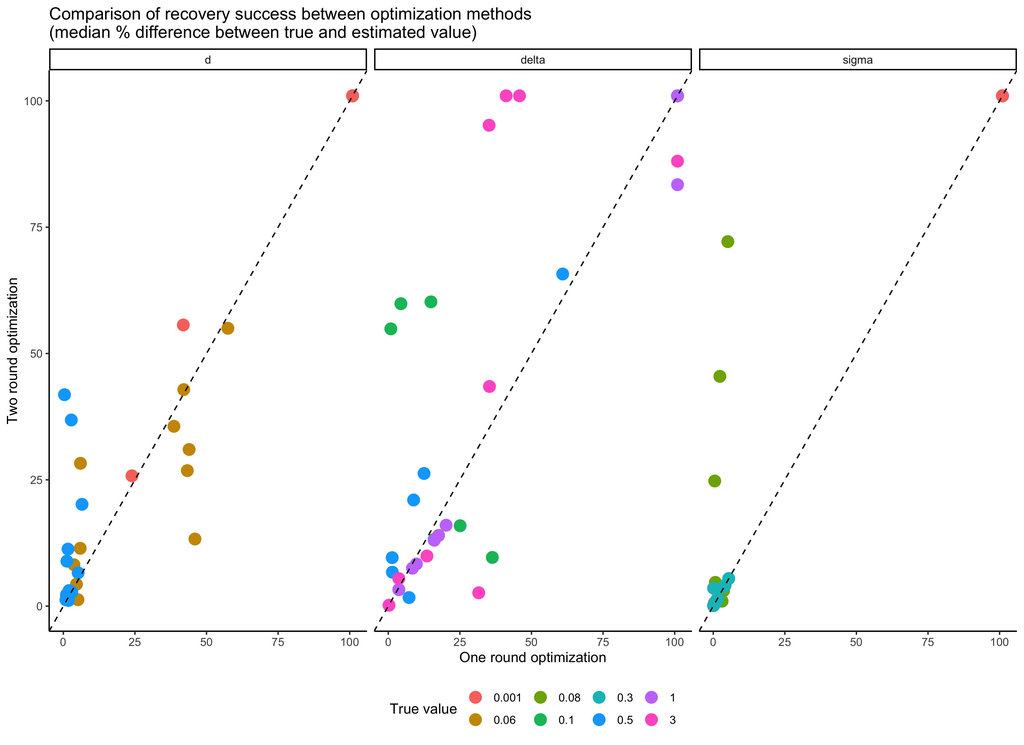

```r
p = comp_data %>%
  mutate(median_diff_clipped = ifelse(median_diff > 100, 101, median_diff)) %>%
  select(-median_diff) %>%
  group_by(key) %>%
  spread(sim_type, median_diff_clipped) %>%
  ggplot(aes(sim3, sim3b, color=as.factor(true_val)))+
  geom_point(size=4)+
  geom_abline(aes(slope=1, intercept=0), linetype="dashed") +
  facet_wrap(~key)+
  labs(title="Comparison of recovery success between optimization methods\n(median % difference between true and estimated value)",
       x="One round optimization",
       y="Two round optimization",
       color= "True value")+
  theme(legend.position = "bottom")

ggsave(file=paste0(fig_out_path, fig_fn, '_diff_pct_comparison.pdf'), p, height = 8, width=11, units="in")
```

Next:  
- If I fit this model to subject’s data, what are the parameter distributions and how good is the fit (fit model using 2/3 and predict left out 1/3)  
- (Kill roptim cluster)  
- Joint choice and RT modeling  
- Hierarchical estimation

Meeting note:  
- Make likelihood surface for one of the recovered delta-gamma correlation scatter plots

More data per optimization? (currently for single subject)

Would you compute posterior among these different optimized values? Is there any point in doing that even when there is no iteration that has converged on the true values?